# Using Rscript

### Learning Objectives:

> - Invoking and running Rscript
> - Understand the command `Rscript`
> - Execute some scripts

## Command Rscript

Another very useful and interesting way to run R in non-interactive mode is the command `Rscript`. This command is officially referred to as the **Scripting Front-End for R** because this is an alternative front end originally designed to be used in bash (#!) scripts and other scripting applications.

- `Rscript` is the alternative front-end of `R CMD BATCH`
- output goes to standard output (*stdout*)
- `Rscript` has default options `--slave --no-restore`

In R, you can check the help documentation with `help(Rscript)`. Also, you can consult the R manual [An Introduction to R](https://cran.r-project.org/doc/manuals/r-release/R-intro.html) and read the section **Scripting with R**

The usage of `Rscript` has the following form:

```bash
Rscript [options] [-e expr [-e expr2 ...] | file] [args]
```

- `options` are options beginning with double dash `--`. These can be any of the standard `R` front-end.
- `expr` (further expressions `expr2 ...`) refers to any R expression, and must be properly quoted
- `file` is the name of the input file containing R commands
- `args` are arguments to be passed to the script in `file`

### Executing simple expressions

One basic use of `Rscript` is to execute simple expressions using the flag `-e`. For example, to compute the sum `2 + 2`, type the following in the command line:

```bash
Rscript -e '2 + 2'
```

You can run more than one expression using as many `-e` flags as expressions to be executed (make sure to properly quote them)

```bash
Rscript -e '2 + 3' -e '2 * 3' -e '2 ^ 3'
```

You can also execute a compound expression with multiple commands separated with semicolons `;`

```bash
Rscript -e '2 + 3; 2 * 3; 2 ^ 3'
```

Here are some more examples that you can try:

```bash
# some math
Rscript -e 'sqrt(81) + abs(-10) - sin(pi/2)'

# some text
Rscript -e 'sprintf("the girl spent $%s in books", 10)'

# quadratic equation
Rscript -e 'a=1; b=2; c=3; x=1; a*x^2 + b*x + c'

# date
Rscript -e 'paste("today is", substr(date(), 1, 10), substr(date(), 21, 24))'

# time
Rscript -e 'paste("the time is", substr(date(), 12, 19))'
```

### Using `Rscript` with R script files

`Rscript` can be used to execute files with R code. If the script file to be run does not require the user to pass arguments, then you can run it in several ways:

```bash
Rscript myscript.R
```

Another alternative is to call the `source()` function via an expression with the `-e` flag (be careful with the quotes):

```bash
Rscript -e 'source("myscript.R")'
```

Here’s one example of how to render an `.Rmd` (R markdown) file from the command line (again, be careful with the quotes):

```bash
Rscript -e 'library(rmarkdown); render("document.Rmd")'
```

Here’s the same command as above, but now swaping the types of quotes:

```bash
Rscript -e "library(rmarkdown); render('document.Rmd')"
```

## Passing arguments to `Rscript`

Some times you want to provide arguments that will be passed to the input file. The way to invoke `Rscript` and passing arguments is like this:

```bash
Rscript script_file.R arg1 arg2
```

- The main command is `Rscript`.
- The name of the input R file is `script_file.R`
- Supplied arguments are: `arg1` and `arg2`

### Toy Example: Normal Vector

Consider the hypothetical example of having a minimalist script `normal-vector.R` that generates a vector of normal random numbers—via the function `rnorm()`. This script could look like:

```r
# vector of random numbers
x <- rnorm(n, mean, sd)
cat(x)
```

In this case, it would be nice if you can supply values for `n`, `mean`, and `sd` when executing the script. For instance, say you want `n` to be 100, `mean` 5, and `sd` 1.5, you could invoke the script as:

```bash
Rscript normal-vector.R 100 5 1.5
```

The folder `scripts/` does actually include such a `normal-vector.R` file for you to test (keep in mind that it is a toy script).

### Extracting Supplied Arguments

So how do you access any supplied arguments when calling `Rscript` from the command line? When you pass arguments to `Rscript`, these can be retrieved as a charactervector with the `commandArgs()` function. For example, including a line like the one below inside the input file:

```r
args <- commandArgs(trailingOnly = TRUE)
```

creates a character vector `args` that contains the supplied arguments. In other words, `commandArgs()` extracts the provided command line arguments.

Let’s take a look at the code in the `normal-vector.R` example:

```r
# reading arguments ('n', 'mean', 'sd')
args <- commandArgs(trailingOnly = TRUE)

n <- as.numeric(args[1])
mean <- as.numeric(args[2])
sd <- as.numeric(args[3])

x <- rnorm(n, mean, sd)
cat(x, '\n')
```

As you can tell from the snippet above, `commandArgs(TRUE)` returns a character vector with the supplied arguments. These values can then be accessed individually (e.g. `args[1]`). Because the arguments are in the form of a character vector, it’s good practice to convert them into numbers with `as.numeric()`.

### More about `commandArgs()`

The function `commandArgs()` takes a logical parameter called `trailingOnly`. If you use the parameter `trailingOnly = FALSE` inside `commandArgs()`, the character vector of arguments will include the default options of calling `Rscript`. For instance, the file `show-args.R` in the `sripts/` folder consists of the following code:

```r
args <- commandArgs(trailingOnly = FALSE)

for (i in 1:length(args)) {
    cat(args[i], '\n')
}
```

which will print all the supplied arguments (even the default ones). When you execute `show-args.R` from the command line without supplying any arguments, you should be able to see an output like the following one:

```bash
Rscript show-args.R
```

```
/Library/Frameworks/R.framework/Resources/bin/exec/R
--slave
--no-restore
--file=show-args.R
```

as you can tell, the output shows four arguments: the first one refers to the location of the executable R; the other values (`--slave`, `--no-restore`, and `--file=show-args.R`) are the default options when calling `Rscript`.

### Excluding default options as arguments

To exclude the default (“non-relevant”) arguments, you have to use `commandArgs(trailingOnly = TRUE)`. The `scripts/` folder of this tutorial contains the script `listing-args.R`. This is a simple R script that reads any provided arguments, and displays the number of arguments as well as their values. You can try it like so:

```bash
# no arguments provided
Rscript listing-args.R

# one argument provided
Rscript listing-args.R 10

# various arguments provided
Rscript listing-args.R 1 a TRUE NA yes
```

### Example: Normal Histogram

Our last example will consider the R script `normal-distribution.R` that produces a histogram from a randomly generated vector. If you look at the code in `normal-histogram.R`, you’ll see that the generated vector has length 1000. Since the vector has a fixed size, we just need to pass arguments for `mean`, and `sd`:

```bash
Rscript normal-distribution.R 0 1
```

If you execute this script, the produced histogram will be saved in the file `normal-histogram.png`

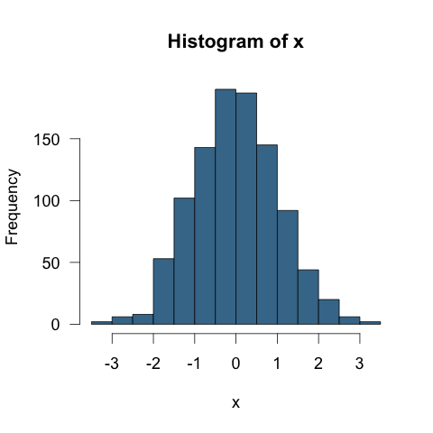

normal-histogram

### Using Rscript in shell scripts

Besides invoking `Rscript` directly from the command line, there is another way to use it inside shell scripts. We’ll discuss this topic in the section `04-bash-script/`.